# Validación Cruzada

Antonio, Marta y Pedro José

2023-02-27

# 0) Introducción.

La estadística es una rama de las matemáticas que se encarga de recolectar, analizar e interpretar datos. Una de las principales aplicaciones de la estadística es el modelado de fenómenos y la predicción de resultados futuros.

Podemos entender el análisis de datos como el procedimiento mediante el cual utilizamos herramientas informáticas junto a técnicas estadísticas para convertir los datos en información la cual analizar y sacar conclusiones útiles para la toma de decisiones.

El objetivo de este proyecto es encontrar el mejor modelo para el conjunto de datos de credit score utilizando técnicas de entrenamiento y validación cruzada, es decir, aquel que tenga el mejor rendimiento en términos de precisión y generalización. Buscamos un modelo con la mayor sensibilidad, es decir la mejor capacidad para predecir los casos negativos en los que no se concede el crédito.

La metodología del código busca ser estructurado, eficiente, reproducible y completo. Estructurado en tanto que está en distintos script, para así facilitar la división del trabajo, poder reutilizar los script por separado y evitar que se arrastren fallos de una tarea a otra. Eficiente tanto computacionalmente como en el número de líneas que se van a escribir. La reproducibilidad se enfoca en tener un código bien comentado y también preparado para reutilizarse con el mínimo de cambios posibles. Completo en el sentido de que vamos a usar todos los modelos y técnicas posibles. Esto último puede entrar en conflicto con la reproducibilidad, por ello solo se seleccionan para ser ejecutados algunos modelos y técnicas.

Este documento es la versión reducida y resumida del trabajo original, gran parte del código no se muestra, este aparece tanto en los scripts como en la versión completa.

En lo referente a la metodología de este documento, resaltar que en todo momento se borran las variables instrumentales por motivos de eficiencia, pero esto queda oculto.

# 1) Preparación y descripción.

## 1.1 Carga y preparación de los datos

En esta parte del trabajo se cargan los datos de un archivo de Excel, se analizan y convierten en factores las variables categóricas para su posterior análisis. Así mismo, se renombran las variables para que el informe se pueda reproducir con mayor facilidad. En el código o versión completa se puede ver más en detalle. También, creamos una clave primaria que nos servirá posteriormente para recuperar los outliers

La relación de nombres de variables es la siguiente:

```r
# mostramos los nuevos nombres
datatable(nombres_df)
```

|  | Original | Nuevo |
| --- | --- | --- |
| 1 | Dictamen | X_1 |
| 2 | Ant.trabajo | X_2 |
| 3 | Vivienda | X_3 |
| 4 | Plazo | X_4 |
| 5 | Edad | X_5 |
| 6 | Estado.civil | X_6 |
| 7 | Tipo.trabajo | X_7 |
| 8 | Gastos | X_8 |
| 9 | Ingresos | X_9 |
| 10 | Patrimonio | X_10 |

[output cut: 3 more lines]

## 1.2 Valores ausentes

En este apartado vamos a identificar posibles valores ausentes y operar los datos para evitar problemas con ellos.

```r
# Recuento de NA (FALSE)
datatable(data.frame(table(complete.cases(df))))
```

|  | Var1 | Freq |
| --- | --- | --- |
| 1 | FALSE | 4 |
| 2 | TRUE | 3940 |

```r
# Observaciones con NA
datatable(df[!complete.cases(df),],fillContainer = TRUE)
```

|  | X_1 | X_2 | X_3 | X_4 | X_5 | X_6 | X_7 | X_8 | X_9 | X_10 | X_11 | X_12 | X_13 | ID |
| --- | --- | --- | --- | --- | --- | --- | --- | --- | --- | --- | --- | --- | --- | --- |
| 1 |  | 2 | alquiler | 36 | 21 | soltero | fijo | 450 | 1000 | 0 | 0 | 7000 | 8250 | ID_3941 |
| 2 |  | 4 | padres | 24 | 27 | soltero | fijo | 350 | 1100 | 0 | 0 | 3700 | 5250 | ID_3942 |
| 3 |  | 6 | alquiler | 48 | 65 | casado | otros | 690 | 2370 | 0 | 0 | 15710 | 15710 | ID_3943 |
| 4 |  | 13 | escritura publica | 60 | 34 | separado | fijo | 350 | 560 | 70000 | 15000 | 12500 | 15250 | ID_3944 |

```r
# Observaciones con NA
which(is.na(df))
```

```
## [1] 3941 3942 3943 3944
```

```r
# NA por variable
colSums(is.na(df))
```

```
##  X_1  X_2  X_3  X_4  X_5  X_6  X_7  X_8  X_9 X_10 X_11 X_12 X_13   ID
##    4    0    0    0    0    0    0    0    0    0    0    0    0    0
```

Identificamos que existen cuatro observaciones con NA en la variable objetivo `X_1`, son observaciones que queremos predecir y las separamos a la tabla `nd`.

```r
nd <- df[which(is.na(df)),]
df <- df[-which(is.na(df)),]
```

## 1.3 Análisis descriptivo.

En este apartado vamos a estudiar nuestros datos para tratar de obtener una visión general y entender su distribución y relaciones. Se trata de un análisis descriptivo y no de diagnóstico, por tanto, no aspiramos a explicar el por qué.

### 1.3.1 Medidas y relaciones

En este apartado emplearemos medidas de resumen de la distribución y las relaciones. Nuestra función `RESUMEN` nos ofrece los principales estadísticos para nuestras variables.

Esto puede hacerse con otras funciones como `summary` o `skimr`.

Observamos que las variables tienen una escala dispar, lo cual solucionaremos posteriormente. Además no parecen pertenecer a una normal, por la diferencia entre su media y mediana así como por su asimetría y curtosis. Otra cuestión relevante es que hay máximos y mínimos muy alejados de los cuartiles, lo que sumado a la diferencia entre media y mediana es indicador de la presencia de outliers.

```r
# resumen estadístico
datatable(RESUMEN(df),fillContainer=TRUE)
```

|  | variable | media | varianza | sd | cv | min | q1 | mediana | q3 | max | dq | asimetria | curtosis |
| --- | --- | --- | --- | --- | --- | --- | --- | --- | --- | --- | --- | --- | --- |
| 1 | X_2 | 8.94035532994924 | 70.5227173146834 | 8.39778049931549 | 0.939311715182484 | 0 | 2 | 6 | 14 | 47 | 12 | 1.205222652903 | 4.22299800125154 |
| 2 | X_4 | 46.3279187817259 | 220.03968746738 | 14.8337347781124 | 0.320189966831913 | 6 | 36 | 48 | 60 | 60 | 24 | -0.781617564899331 | 2.57558223328901 |
| 3 | X_5 | 37.5210659898477 | 122.267390587165 | 11.0574585953177 | 0.294700011942879 | 18 | 28 | 36 | 46 | 68 | 18 | 0.486181725881784 | 2.35900194233734 |
| 4 | X_8 | 570.875634517766 | 38360.0099164544 | 195.857116073056 | 0.34308193278997 | 350 | 440 | 590 | 750 | 1730 | 310 | 0.872592954009432 | 3.92786692703314 |
| 5 | X_9 | 1501.0076142132 | 726252.068995068 | 852.204241361816 | 0.567754775720126 | 60 | 990 | 1300 | 1800 | 9590 | 810 | 2.63947647129614 | 16.0021720888934 |
| 6 | X_10 | 53847.5812182741 | 10537525502.5258 | 102652.450056128 | 1.90635210967082 | 0 | 0 | 35000 | 60000 | 2000000 | 60000 | 8.11424973612078 | 109.048246055841 |
| 7 | X_11 | 3425.30203045685 | 126614041.416751 | 11252.2904964612 | 3.28505060178896 | 0 | 0 | 0 | 0 | 214000 | 0 | 6.9773886330916 | 88.0946168697034 |
| 8 | X_12 | 10012.3350253807 | 19357328.2858001 | 4399.69638563845 | 0.43942760349963 | 1000 | 7000 | 10000 | 12500 | 38750 | 5500 | 0.862119498327265 | 5.65916464702526 |
| 9 | X_13 | 14449.078680203 | 36106962.2634194 | 6008.90691086319 | 0.415867824091519 | 1250 | 11257.5 | 13860 | 16632.5 | 111400 | 5375 | 3.42777523398612 | 38.0866530951196 |

Calculamos las proporción de las clases de nuestra variable objetivo. Están desequilibradas, lo cual puede hacer imprecisos a los clasificadores por clase.

```r
# mostramos
datatable(p_priori,fillContainer=TRUE)
```

|  | X_1 | n_observaciones | p_priori |
| --- | --- | --- | --- |
| 1 | negativo | 500 | 0.126903553299492 |
| 2 | positivo | 3440 | 0.873096446700508 |

Mediante las matrices de covarianzas y correlaciones podemos tratar de entender las relaciones entre las variables.

```r
# matriz varianzas - covarianzas
covarianzas <- df |> select(where(is.numeric)) |> cov() |> round(3)

# matriz correlaciones
correlaciones <- df |> select(where(is.numeric)) |> cor() |> round(3)
datatable(correlaciones,fillContainer=TRUE)
```

|  | X_2 | X_4 | X_5 | X_8 | X_9 | X_10 | X_11 | X_12 | X_13 |
| --- | --- | --- | --- | --- | --- | --- | --- | --- | --- |
| X_2 | 1 | -0.019 | 0.527 | 0.137 | 0.11 | 0.142 | -0.025 | 0.018 | 0.045 |
| X_4 | -0.019 | 1 | -0.081 | -0.026 | -0.047 | -0.093 | 0.065 | 0.443 | 0.101 |
| X_5 | 0.527 | -0.081 | 1 | 0.245 | 0.151 | 0.227 | -0.059 | 0.005 | 0.019 |
| X_8 | 0.137 | -0.026 | 0.245 | 1 | 0.286 | 0.045 | 0.03 | 0.044 | 0.043 |
| X_9 | 0.11 | -0.047 | 0.151 | 0.286 | 1 | 0.253 | 0.169 | 0.227 | 0.24 |
| X_10 | 0.142 | -0.093 | 0.227 | 0.045 | 0.253 | 1 | 0.145 | 0.203 | 0.287 |
| X_11 | -0.025 | 0.065 | -0.059 | 0.03 | 0.169 | 0.145 | 1 | 0.053 | 0.047 |
| X_12 | 0.018 | 0.443 | 0.005 | 0.044 | 0.227 | 0.203 | 0.053 | 1 | 0.673 |
| X_13 | 0.045 | 0.101 | 0.019 | 0.043 | 0.24 | 0.287 | 0.047 | 0.673 | 1 |

### 1.3.2 Análisis gráfico.

Mediante el uso de visualizaciones podemos complementar las medidas y lograr una mejor comprensión de nuestros datos.

El siguiente código crea un histograma y gráfico de densidad para cada una de nuestras variables:

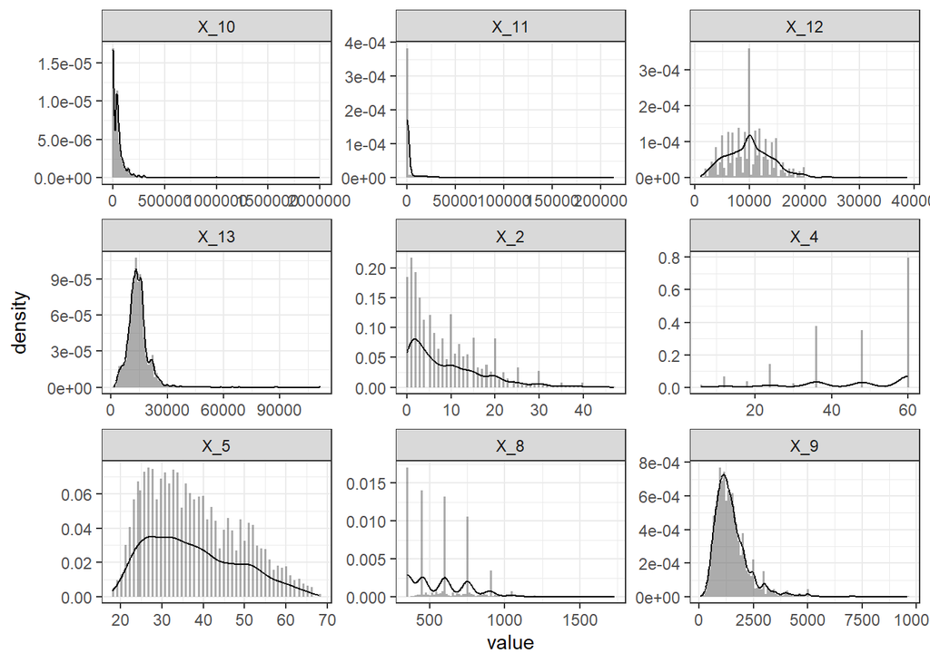

```r
ggplot(gather(df |> select(where(is.numeric)), variable, value), aes(x = value)) +
  geom_histogram(aes(y = after_stat(density)),
                 alpha = 0.5, position = "identity",bins=100) + # histogrmas
  geom_density(alpha = 0.5) + # densidad teorica
  facet_wrap(~ variable, scales = "free")+
  theme_bw() # tema
```

Podemos estudiar cuales se comportan de forma más o menos normal. Colas largas podrían indicar outliers, las distribuciones multimodales pueden indicar grupos.

Los gráficos de caja y bigotes muestran información sobre la distribución pero de forma simplificada y fácil de analizar. Los puntos fuera de los bigotes (rango intercuantílico) son potenciales outliers. Dado que el código es similar al histograma, no se muestra.

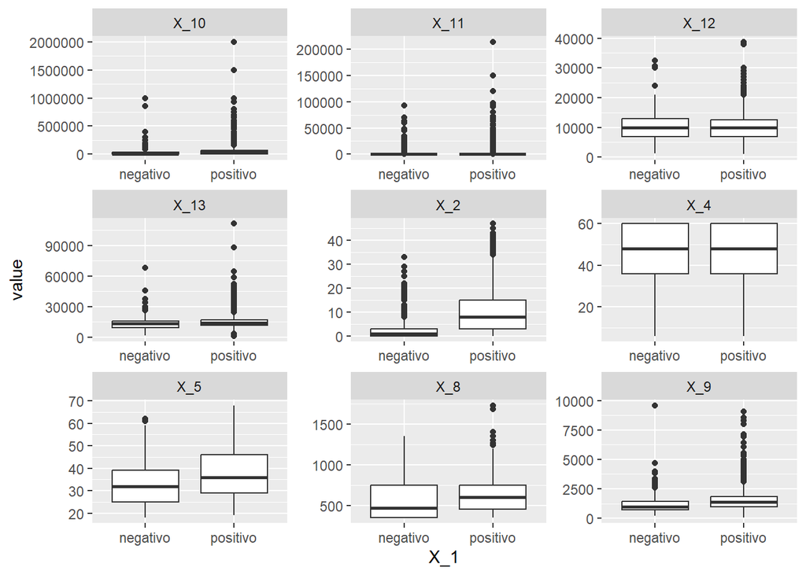

Una versión más completa de estos son los llamados gráficos de violin, que además, muestran la densidad:

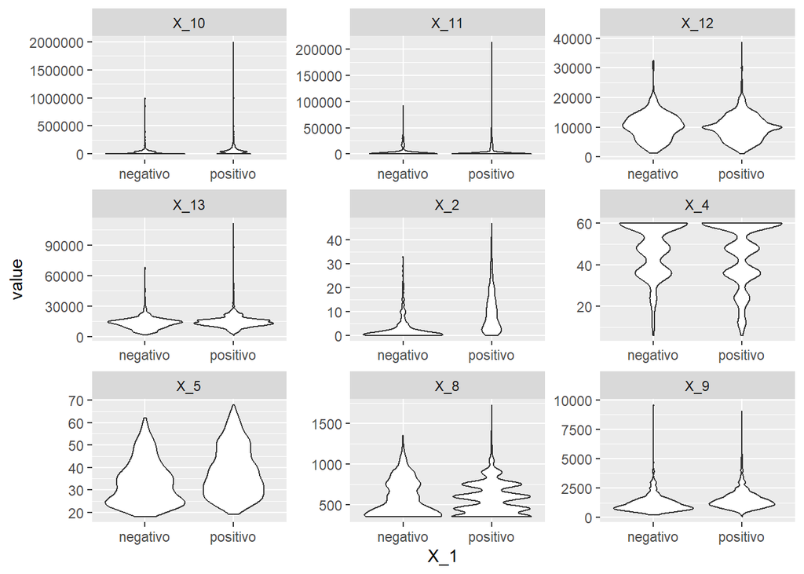

También podemos ver de forma gráfica las correlaciones entre variables:

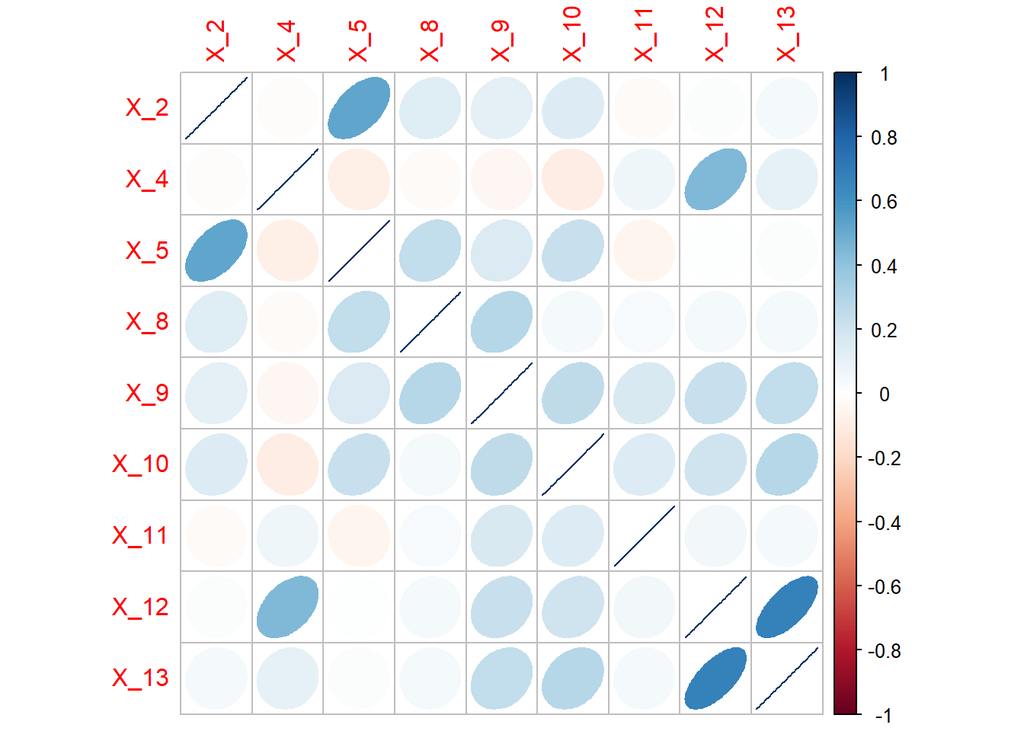

```r
corrplot(correlaciones,'ellipse')
```

## 1.4 Homogenización.

Nuestras variables presentan una escala muy diferente, lo cual puede perjudicar la precisión de los clasificadores, sobre todo aquellos basados en distancias, así como la detección de outliers. Además, una similar escala facilita comparaciones.

El método que vamos a utilizar es tipificar nuestros datos, de forma que quedan con media 0 y varianza 1. Pero hay otras alternativas como tomar logaritmos o normalizar.

# 2) Detección de Anomalías.

El objetivo de este apartado es emplear distintas técnicas para detectar posibles outliers. Esto es importante pues la presencia de estos datos anómalos puede perjudicar la estimación de estadísticos, lo que nos puede llevar a una menor precisión.

En el trabajo hemos probado múltiples técnicas, lo que incluye: estadísticas univariantes y multivariantes así cómo métodos clúster. Por motivos de espacio, solo vamos a mostrar la técnica LOF, pero el resto están en el código y en la versión completa.

Descartamos los métodos univariantes pues no tienen en consideración posibles correlaciones o tendencias, rechazamos la distancia de Mahalanobis estándar y robusta pues nuestros datos no cumplen la hipótesis de distribución normal multivariante. Nos quedamos con LOF que no hace asunciones tan restrictivas.

En primer lugar realizamos unos pasos previos; guardar los datos originales y retirar `X_11` que provoca problemas en algunas técnicas.

### 2.1 Contrastes de normalidad.

Hay ténicas de detección de outliers, de clasificación y para equilibrar las probabilidades a priori que se basan en la asunción de una distribución normal. Por ello, vamos a tratar de contrastar esta asunción mediante el test de Shapiro-Wilks cuya hipótesis nula es la existencia de normalidad en una variable.

```r
# Saphiro Test

# Ho Normal

# para una variable

shapiro.test(df[,2])
```

```
##
##  Shapiro-Wilk normality test
##
## data:  df[, 2]
## W = 0.87988, p-value < 2.2e-16
```

```r
# para todas las variables por clase

df %>%
  group_by(X_1) %>%
  select(where(is.numeric)) %>%
  summarise_all(list(~ shapiro.test(.)$p.value)) %>%
  ungroup()
```

```
## # A tibble: 2 × 9
##   X_1         X_2      X_4      X_5      X_8      X_9     X_10     X_12     X_13
##   <fct>     <dbl>    <dbl>    <dbl>    <dbl>    <dbl>    <dbl>    <dbl>    <dbl>
## 1 negat… 1.33e-31 1.35e-23 4.51e-13 1.50e-19 3.75e-27 1.18e-39 4.48e- 9 5.08e-20
## 2 posit… 6.01e-43 4.06e-51 4.08e-29 6.05e-43 1.72e-53 5.79e-73 1.42e-30 1.88e-53
```

Contrastamos las variables por grupos porque la ausencia de normalidad puede deberse a la existencia de grupos que se reflejen en una distribución multimodal.

Advertencia: el test de Saphiro-Wilks en R 4.2.2 tiene como límite 5000 observaciones.

## 2.2 LOF.

En este apartado vamos a emplear el método LOF (Local Outlier Factor) que se basa en comparar relativamente la distancia de una observación a sus K vecinos más cercanos con la media de distancias existente entre estos. De forma que una observación obtiene una puntuación elevada no solo por estar muy alejada sino también si se comporta de forma diferente a sus vecinos.

Utilizamos como heurística para seleccionar K la raíz del número de observaciones.

```r
lof_scores <- df %>%
  select(where(is.numeric)) %>%
  LOF(round(sqrt(dim(df)[1]),0))
```

Para remover outliers vamos a seleccionar solo el 5% con mayor LOF, ya que no tiene sentido que los outliers sean una proporción muy elevada, pues en ese caso ya no serían anómalos.

El código agrega a los datos una columna de LOF score, los ordena de forma descendiente según LOF, retira los n primeros y quita la nueva columna.

```r
# borramos un 5%
n <- round(0.05*dim(df)[1],0)

df <- df %>%
  mutate(lof_score = LOF(select_if(., is.numeric), k = round(sqrt(n()),0))) %>%
  arrange(desc(lof_score)) %>%
  slice(-(1:n)) %>%
  select(-lof_score)
```

Hemos ordenado los datos y eso podría alterar algunas técnicas, por tanto los reordenamos aleatoriamente.

```r
# remezclamos los datos
df <- df[sample(1:dim(df)[1],dim(df)[1]),]
```

## 2.3 Análisis de las anomalias

Hemos creado un data frame con los outliers mediante `anti_join`.

Una métrica importante es la proporción de outliers:

```r
# proporcion de outliers
dim(df_outliers)[1]/dim(df_original)[1]
```

```
## [1] 0.05
```

Además podemos realizar estadística descriptiva sobre nuestros outliers.

Mediante `skim` calculamos las principales estadísticas:

```r
skim(df_outliers)
```

Data summary

| Name | df_outliers |
| --- | --- |
| Number of rows | 197 |
| Number of columns | 12 |
| _______________________ |  |
| Column type frequency: |  |
| factor | 4 |
| numeric | 8 |
| ________________________ |  |
| Group variables | None |

**Variable type: factor**

| skim_variable | n_missing | complete_rate | ordered | n_unique | top_counts |
| --- | --- | --- | --- | --- | --- |
| X_1 | 0 | 1 | FALSE | 2 | pos: 181, neg: 16 |
| X_3 | 0 | 1 | FALSE | 5 | esc: 123, alq: 36, pad: 24, otr: 8 |
| X_6 | 0 | 1 | FALSE | 5 | cas: 156, sol: 33, sep: 4, viu: 3 |
| X_7 | 0 | 1 | FALSE | 4 | aut: 103, fij: 81, otr: 7, tem: 6 |

**Variable type: numeric**

| skim_variable | n_missing | complete_rate | mean | sd | p0 | p25 | p50 | p75 | p100 | hist |
| --- | --- | --- | --- | --- | --- | --- | --- | --- | --- | --- |
| X_2 | 0 | 1 | 0 | 1 | -1.09 | -0.80 | -0.32 | 0.73 | 3.22 | ▇▃▂▁▁ |
| X_4 | 0 | 1 | 0 | 1 | -2.09 | -1.05 | 0.34 | 1.03 | 1.03 | ▂▃▃▃▇ |
| X_5 | 0 | 1 | 0 | 1 | -1.84 | -0.83 | 0.10 | 0.88 | 1.81 | ▆▆▇▇▆ |
| X_8 | 0 | 1 | 0 | 1 | -1.02 | -0.70 | -0.22 | 0.52 | 3.41 | ▇▅▁▁▁ |
| X_9 | 0 | 1 | 0 | 1 | -1.19 | -0.75 | -0.22 | 0.57 | 3.53 | ▇▅▂▁▁ |
| X_10 | 0 | 1 | 0 | 1 | -0.85 | -0.70 | -0.25 | 0.20 | 5.18 | ▇▂▁▁▁ |
| X_12 | 0 | 1 | 0 | 1 | -1.59 | -0.77 | -0.26 | 0.63 | 3.13 | ▅▇▃▂▁ |
| X_13 | 0 | 1 | 0 | 1 | -1.29 | -0.65 | -0.33 | 0.42 | 5.78 | ▇▃▁▁▁ |

Es interesante compararla con los datos originales y esto se hace en la versión completa.

Podemos estudiar gráficamente la distribución de los outliers mediante un histograma y gráfico de densidad:

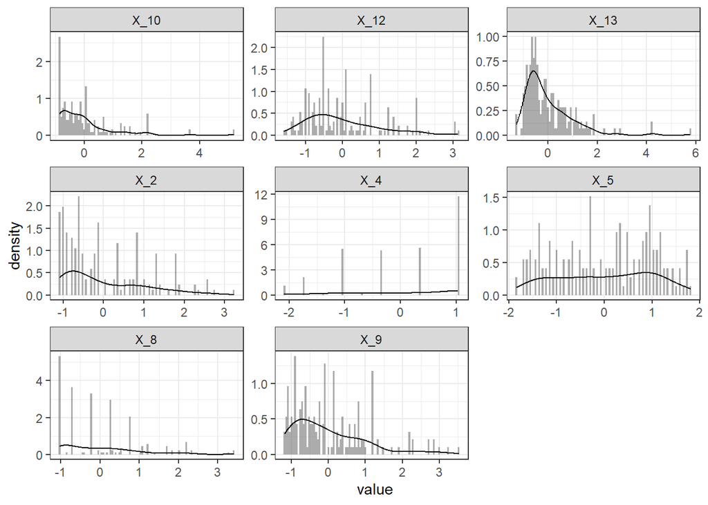

A su vez, lo comparamos con los datos principales.

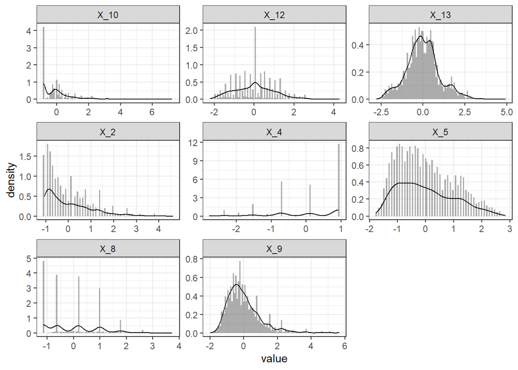

Cuanto más diferentes sean las distribuciones, más anómalos son los datos.

Podemos comparar mediante un boxplot los outliers y normales:

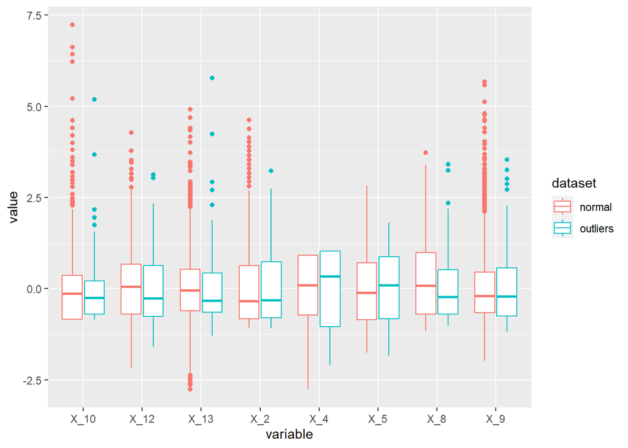

# 3) Equilibrio en probabilidades a priori

Nuestras probabilidades a priori están desequilibradas:

|  | X_1 | n_observaciones | p_priori |
| --- | --- | --- | --- |
| 1 | negativo | 500 | 0.126903553299492 |
| 2 | positivo | 3440 | 0.873096446700508 |

Y esto puede perjudicar la precisión de los clasificadores por clase, en consecuencia, el objetivo del apartado es solucionar este problema.

Definimos un objeto con nuestra clase minoritaria para ir usándolo:

```r
# clase minoritaria
clase <- 'negativo'
```

Al igual que con la detección de las anomalías, en nuestro trabajo hemos utilizado múltiples técnicas, en cambio, por brevedad aquí solo mostraremos la técnica elegida. Esta es mediante bootstrap, es decir, equilibrar mediante generar datos tomando muestras aleatorias con remplazamiento de nuestra clase minoritaria.

El motivo de elegir una técnica de generación en lugar de reducción es no perder información. Escogemos el bootstrap por su sencillez y buenos resultados.

Calculamos el número de observaciones a generar para lograr unas probabilidades de 0.6 mayoritarias y 0.4 minoritarias con nuestra función `n_deseada`.

```r
# numero de observaciones necesarias
n <- n_deseada(c(0.6,0.4),c(dim(df %>% filter(X_1!=clase))[1],
                            dim(df %>% filter(X_1==clase))[1]),'sobremuestreo')
```

```r
# creamos muestra de size n de clase minoritaria

# semilla aleatoria
set.seed(1998)

# replica bootstrap
df_negativos<-df %>% filter(X_1 == clase) %>%
  sample_n(size = n, replace = TRUE)
```

Comprobamos que nuestras probabilidades a priori son 0.6 y 0.4:

|  | X_1 | n_observaciones | p_priori |
| --- | --- | --- | --- |
| 1 | negativo | 2173 | 0.400036818851252 |
| 2 | positivo | 3259 | 0.599963181148748 |

# 4) Selección mejor modelo enfoque train/test

## 4.1. Preparación previa.

En este apartado vamos a realizar los pasos previos necesarios a la seleción del mejor modelo mediante el enfoque train/test.

En primer lugar separamos los datos en un conjunto de entrenamiento para alimentar la estimación de los modelos y en un conjunto de test para validar su capacidad de generalización fuera de los datos de entrenamiento.

```r
# numero de observaciones
n <- dim(df)[1]

# dividimos muestra en train y test

# fijamos semilla de aleatoriedad
set.seed(102)

#Train 70% aleatorio
train = sample(1:n, 0.70*n,replace = FALSE)
```

Guardamos las clases reales:

```r
# clase real en test
test.clase <- df[-train,]$X_1

# clase real en entrenamiento
train.clase <- df[train,]$X_1
```

Creamos una fórmula con las variables que vamos a emplear:

```r
# formula
formula <- formula(X_1~.)
```

Nosotros utilizaremos todas las variables, pero lo idóneo sería hacer una selección de las mismas por ejemplo mediante el criterio de Akaike de forma automática o seleccionandolas de forma manual empleando contrastes o conocimientos teóricos.

## 4.2. Estimación de los modelos y su precisión.

En este apartado vamos a estimar los modelos y medir su precisión, dado que el código puede ser repetitivo, solo lo vamos a incluir para el primer modelo.

### 4.2.1. Naive Bayes

El clasificador bayesiano ingenuo se fundamenta en el teorema de Bayes para obtener la probabilidad a posteriori de pertenencer a la clase usando la distribución de frecuencias de las variables por clase.

El modelo se estima de la siguiente manera:

```r
# estimacion del modelo
nb.fit <- naiveBayes(formula , data = df ,subset = train)
```

Una vez estimado el modelo, predecimos y medimos su precisión:

```r
# Prediccion

# train
nb.clase.train <- predict(nb.fit , df[train,]) # clase

# test
nb.clase.test <- predict(nb.fit , df[-train,]) # clase
```

|  | Modelo | Train_Test | Precisión | Kappa | Sensibilidad | Especificidad | Llamada |
| --- | --- | --- | --- | --- | --- | --- | --- |
| 1 | Naive Bayes | Train | 0.802998421883219 | 0.59272228523047 | 0.786524349566378 | 0.813721233174121 | nb.fit |
| 2 | Naive Bayes | Test | 0.819631901840491 | 0.630879720490866 | 0.807121661721068 | 0.828451882845188 | nb.fit |

La columna `Llamada` nos permitirá más adelante seleccionar el mejor modelo.

### 4.2.2 K Nearest Neighbors KNN

El algoritmo KNN busca los K vecinos más cercanos a una observación y asigna la clase mayoritaria entre ellos.

El modelo se estima con la función `train.kknn`

```r
# heuristica de mejor K
K <- round(sqrt(dim(df)[1]))

# buscamos como mucho hasta el doble de K
knn.fit<-train.kknn(formula, data = df[train,], kmax = 2*K)
# usar K -> quitamos kmax y ponemos ks=K

# mejor K
knn.fit$best.parameters[2]
```

```
## $k
## [1] 1
```

De nuevo, predecimos y calculamos la precisión del modelo:

|  | Modelo | Train_Test | Precisión | Kappa | Sensibilidad | Especificidad | Llamada |
| --- | --- | --- | --- | --- | --- | --- | --- |
| 1 | KNN | Train | 0.998947922146239 | 0.997796318251754 | 0.99733155436958 | 1 | knn.fit |
| 2 | KNN | Test | 0.962576687116564 | 0.923463693171234 | 0.982195845697329 | 0.948744769874477 | knn.fit |

### 4.2.3 Clasificación logística.

La clasificación logística estima las probabilidades a posteriori con una función logística y a partir de un umbral (tradicionalmente 0.5) clasifica. Se emplea habitualmente en problemas dicotómicos, pero su versión multinomial se puede emplear en problemas con más de dos clases.

La estimación la hacemos con `train` o `multinom` según el caso.

```r
# estimacion
log.fit <- train(formula, data = df[train,],
                 method = "glm", family = "binomial")

# para clasificacion no binaria
# log.fit <- multinom(formula , family = binomial, data = df, subset=train)
```

Podemos estudiar la importancia de las variables:

```r
# importancia variables
summary(log.fit)$coefficients %>%
  data.frame() %>% arrange(Estimate) %>%
  datatable(fillContainer=TRUE)
```

|  | Estimate | Std..Error | z.value | Pr...z.. |
| --- | --- | --- | --- | --- |
| X_7temporal | -4.42497324103612 | 0.251763593107395 | -17.5759059775913 | 3.76822563923308e-69 |
| X_7otros | -2.72747253603169 | 0.258467802061518 | -10.552465391347 | 4.9481388501201e-26 |
| X_6separado | -1.5345284107364 | 0.313734276849808 | -4.89117231991522 | 1.00237159002877e-06 |
| X_6soltero | -0.963423675365448 | 0.174916401748065 | -5.50790929688275 | 3.63120408178345e-08 |
| X_6divorciado | -0.959528226752572 | 0.615887153474714 | -1.55796109943048 | 0.119242469882299 |
| X_12 | -0.888062313248844 | 0.104519316945312 | -8.49663334207883 | 1.95168701453794e-17 |
| X_8 | -0.772475133370579 | 0.0762049379458018 | -10.1368120517331 | 3.7927535327563e-24 |
| X_3otros | -0.440854604901085 | 0.222190956469623 | -1.98412488026423 | 0.0472419201333891 |
| `X_3contrato privado` | -0.329977219340997 | 0.248081778834336 | -1.33011469399915 | 0.183480484869197 |
| X_6viudo | -0.237056332484108 | 0.410446062031621 | -0.577557819194877 | 0.563562691876768 |

[output cut: 11 more lines]

De nuevo, predecimos y calculamos la precisión:

|  | Modelo | Train_Test | Precisión | Kappa | Sensibilidad | Especificidad | Llamada |
| --- | --- | --- | --- | --- | --- | --- | --- |
| 1 | Logistica | Train | 0.870594423987375 | 0.719536897571168 | 0.738492328218812 | 0.956578376031264 | log.fit |
| 2 | Logistica | Test | 0.882208588957055 | 0.751158493338465 | 0.775964391691395 | 0.957112970711297 | log.fit |

### 4.2.4 Analisis Discriminante Lineal (LDA)

El LDA trata de buscar la combinación de funciones lineales que mejor discriminan los datos basandose en el teorema de Bayes.

La estimación se hace con la función `lda`

```r
# estimacion
lda.fit <- lda(formula , data = df , subset = train)
```

Podemos ver la clase que se asigna según la puntuación:

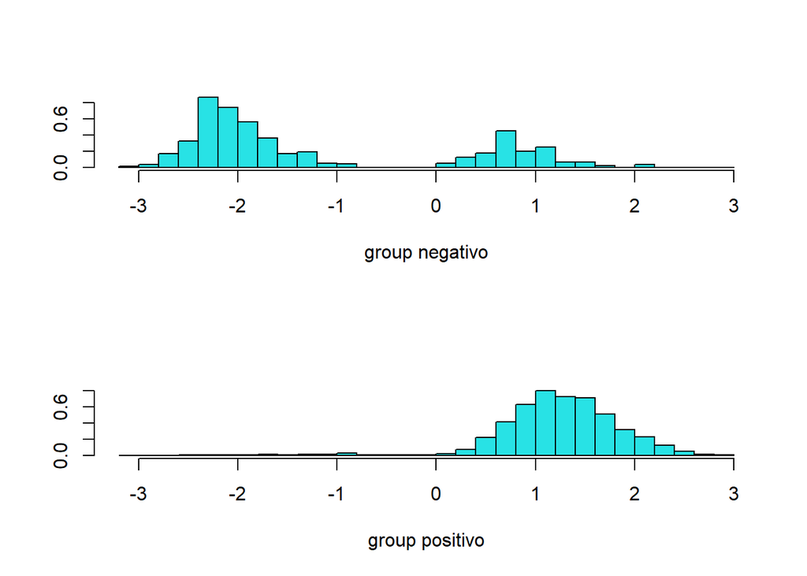

```r
# Grafico
plot(lda.fit)
```

También, con valores tipificados podemos estudiar la importancia de las variables

|  | LD1 |
| --- | --- |
| X_7temporal | 2.70961970816295 |
| X_7otros | 2.17127334614876 |
| X_6separado | 0.619052308227196 |
| X_6soltero | 0.36530974423799 |
| X_6divorciado | 0.359281666320267 |
| X_12 | 0.324355622940047 |
| X_7fijo | 0.320619647329648 |
| X_8 | 0.307864416257173 |
| X_13 | 0.208014464445901 |
| X_3escritura publica | 0.201144528697359 |

[output cut: 10 more lines]

De nuevo predecimos y calculamos la precisión:

|  | Modelo | Train_Test | Precisión | Kappa | Sensibilidad | Especificidad | Llamada |
| --- | --- | --- | --- | --- | --- | --- | --- |
| 1 | LDA | Train | 0.867701209889532 | 0.710650374939896 | 0.709806537691795 | 0.970473295701259 | lda.fit |
| 2 | LDA | Test | 0.877914110429448 | 0.74016351026385 | 0.746290801186944 | 0.97071129707113 | lda.fit |

Otras medidas de precisión importantes en LDA son la Lambda de Wilks y la correlación canónica. Estas se obtienen con `manova`.

```
##             Df   Wilks approx F num Df den Df    Pr(>F)
## df$X_1       1 0.73644   242.61      8   5423 < 2.2e-16 ***
## Residuals 5430
## ---
## Signif. codes:  0 '***' 0.001 '**' 0.01 '*' 0.05 '.' 0.1 ' ' 1
```

```
## [1] 0.7364353
```

```
## [1] 0.2635647
```

```
## [1] 0.5133856
```

### 4.2.5 Analisis Discriminante Cuadratico (QDA)

El QDA trata de buscar la combinación de funciones cuadráticas que mejor discriminan los datos basandose en el teorema de Bayes.

La estimación se hace con la función `qda`

```r
# estimacion
qda.fit <- qda(formula , data = df , subset = train)
```

Predecimos y calculamos la precisión:

|  | Modelo | Train_Test | Precisión | Kappa | Sensibilidad | Especificidad | Llamada |
| --- | --- | --- | --- | --- | --- | --- | --- |
| 1 | QDA | Train | 0.859547606522883 | 0.697128350205881 | 0.738492328218812 | 0.938341293964394 | qda.fit |
| 2 | QDA | Test | 0.862576687116564 | 0.710981011756436 | 0.767062314540059 | 0.929916317991632 | qda.fit |

### 4.2.6 Árbol de clasificación

El árbol de clasificación es un algoritmo voraz que calcula todas las particiones posibles en todas las variables y selecciona aquella que minimiza la variación de una medida de desorden como la función de entropía o el coeficiente de Gini, acto seguido reitera hasta que clasifica a la perfección los datos de entrenamiento o alcanza un criterio de parada.

Podemos estudiar la importancia de las variables:

Mediante el gráfico de coste/complejidad podemos decidir como podar el árbol:

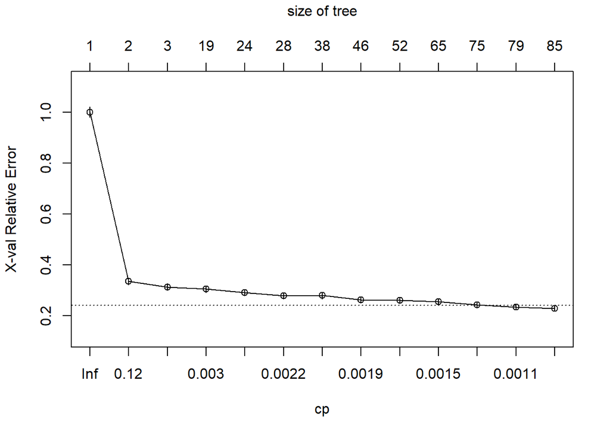

```r
# error nodos vs coste complejidad
plotcp(tree.fit)
```

```r
# podado manual maxdepth en base a plotcp
```

Nosotros vamos a podarlo con `autoprune` de la librería `adabag`.

```r
# podado automatico
tree.fit <- autoprune(formula=formula, data=df, subset=train)
```

Podemos representarlo gráficamente, ponemos un ejemplo con 3 nodos por motivos de espacio:

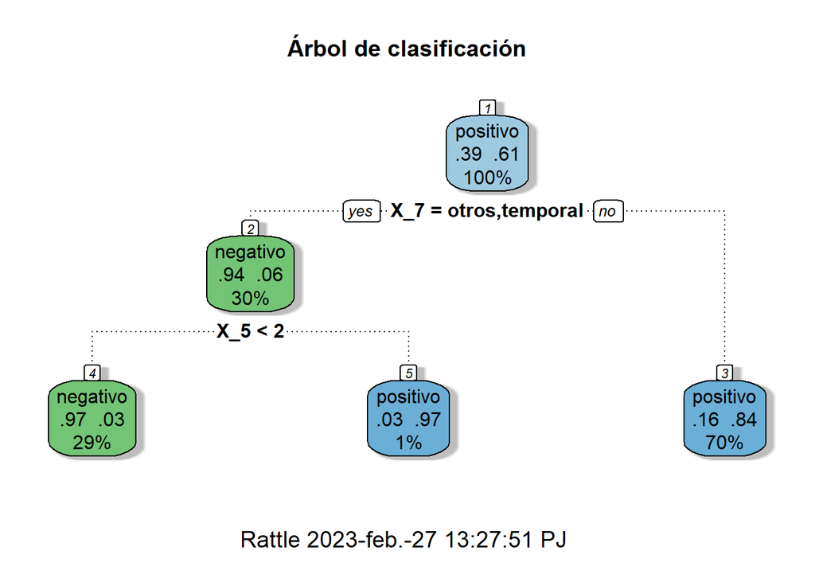

Si tiene muchos nodos, el gráfico puede ser un poco contraintuitivo.

Podemos ver gráficamente la importancia de las variables:

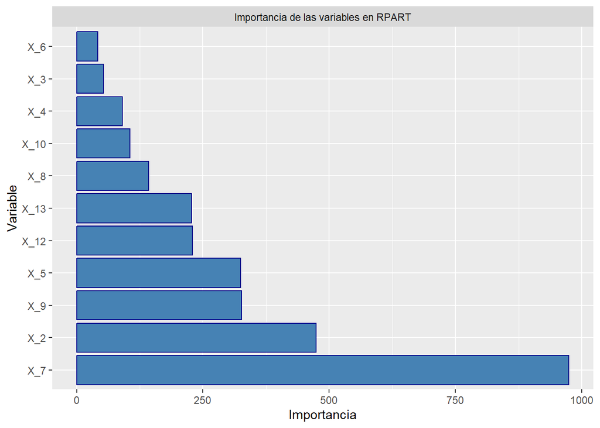

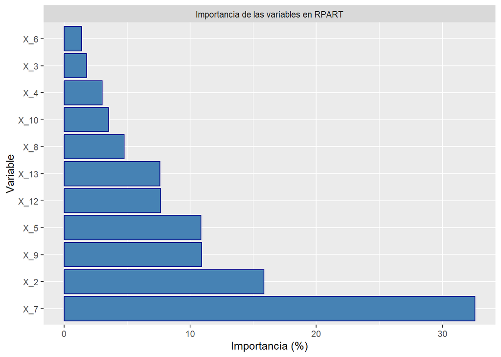

Como acostumbramos, predecimos y calculamos las medidas de precisión:

|  | Modelo | Train_Test | Precisión | Kappa | Sensibilidad | Especificidad | Llamada |
| --- | --- | --- | --- | --- | --- | --- | --- |
| 1 | Arbol | Train | 0.998947922146239 | 0.997798370203298 | 1 | 0.998263135041251 | tree.fit |
| 2 | Arbol | Test | 0.958895705521472 | 0.916335076448336 | 0.99406528189911 | 0.934100418410042 | tree.fit |

### 4.2.7 Bagging

El bagging consiste en crear réplicas bootstrap de los datos, estimar un modelo para cada una de ellas y unir los resultados. En nuestro caso los modelos serán árboles.

Estimamos de la siguiente manera:

```r
# estimacion
bag.fit<- bagging(formula=formula,
                  data=df,
                  subset=train,
                  mfinal=mfinal,
                  control=cntrl)
```

Podemos representar gráficamente la importancia de las variables:

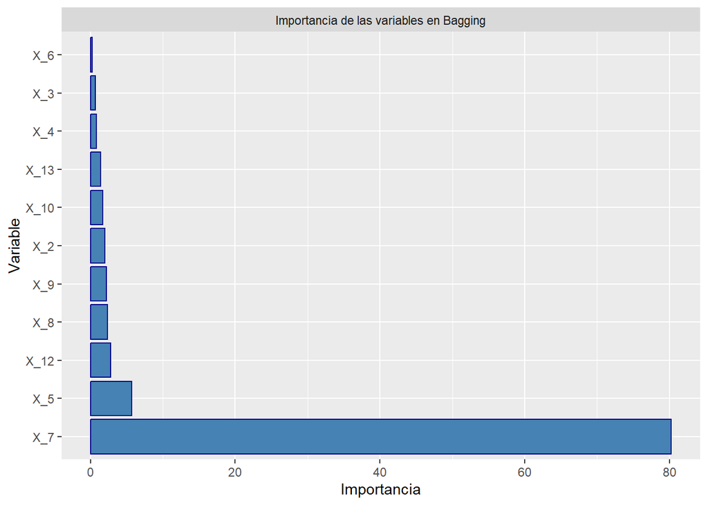

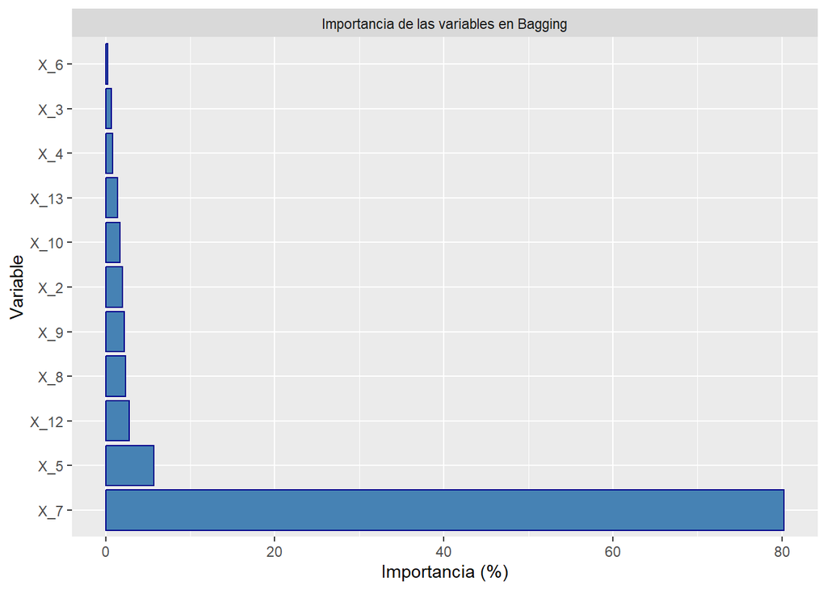

Predecimos y estimamos la precisión:

|  | Modelo | Train_Test | Precisión | Kappa | Sensibilidad | Especificidad | Llamada |
| --- | --- | --- | --- | --- | --- | --- | --- |
| 1 | Bagging | Train | 0.896633350867964 | 0.775240007473016 | 0.762508338892595 | 0.983933999131568 | bag.fit |
| 2 | Bagging | Test | 0.915950920245399 | 0.822640058836704 | 0.820474777448071 | 0.98326359832636 | bag.fit |

### 4.2.8 Boosting

El boosting es similar al bagging, consiste en crear una réplica bootstrap de los datos y secuencialmente estimar modelos, solo que sobre los errores del primero se construye la siguiente réplica dándoles más importancia.

Estimamos el modelo con la siguiente función:

```r
# estimacion
boost.fit<- boosting(formula=formula, data=df, subset=train ,mfinal=mfinal,
                     coeflearn="Freund", boos=T, control=cntrl)
```

También podemos mostrar gráficamente la importancia de las variables:

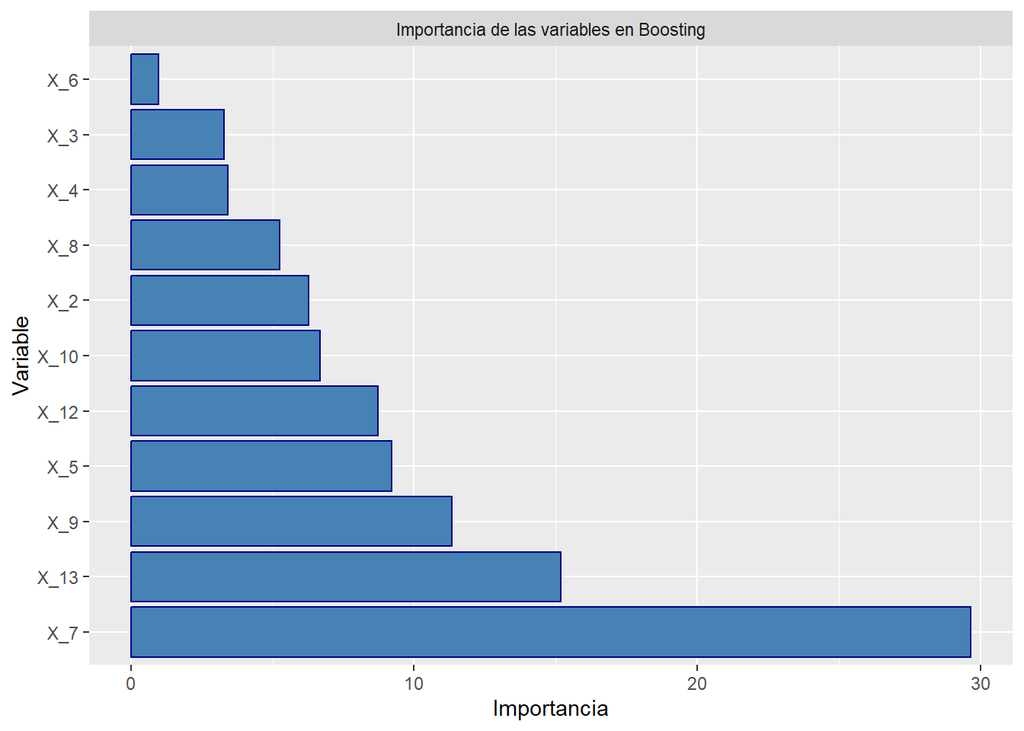

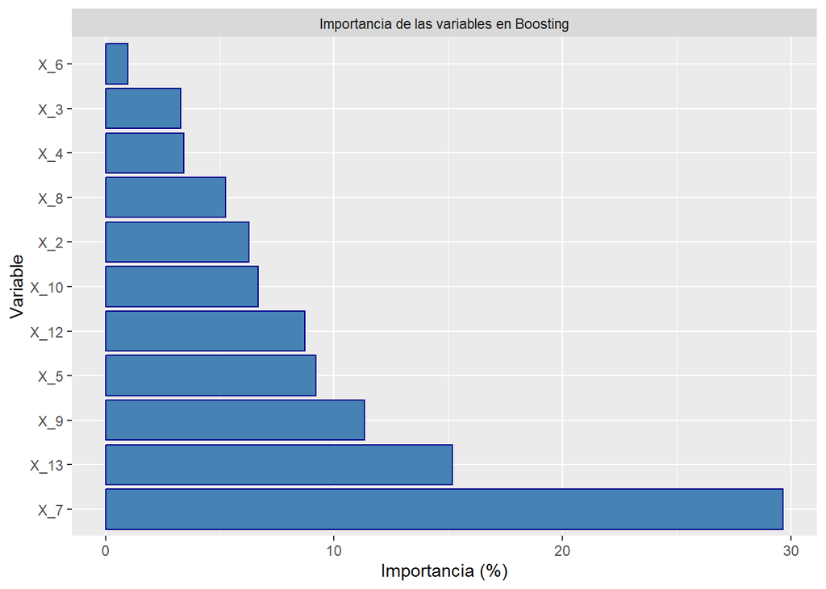

De nuevo predecimos y estimamos la precisión:

|  | Modelo | Train_Test | Precisión | Kappa | Sensibilidad | Especificidad | Llamada |
| --- | --- | --- | --- | --- | --- | --- | --- |
| 1 | Boosting | Train | 0.99079431877959 | 0.98075142212665 | 0.991994663108739 | 0.990013026487191 | boost.fit |
| 2 | Boosting | Test | 0.995092024539877 | 0.989894449696989 | 0.998516320474777 | 0.992677824267782 | boost.fit |

### 4.2.9 Random Forest

El algoritmo de Random Forest también construye varias réplicas aleatorias de los datos, pero además selecciona `m` variables aleatorias para cada estimación, para evitar que ciertas variables acaparen todas las iteraciones eclipsando al resto.

Tomamos `m` como la raíz del número de variables. Se estima de la siguiente forma:

```r
# mtry=sqr(p) para clasificacion
forest.fit<- randomForest(formula=formula, data=df,
                          subset=train, ntree=mfinal,
                          mtry=round(sqrt(dim(df)[2])), nodesize=1,
                          replace=T, importance=T)
```

De nuevo podemos estudiar la importancia de las variables, solo que en este caso mediante la reducción del coeficiente de Gini:

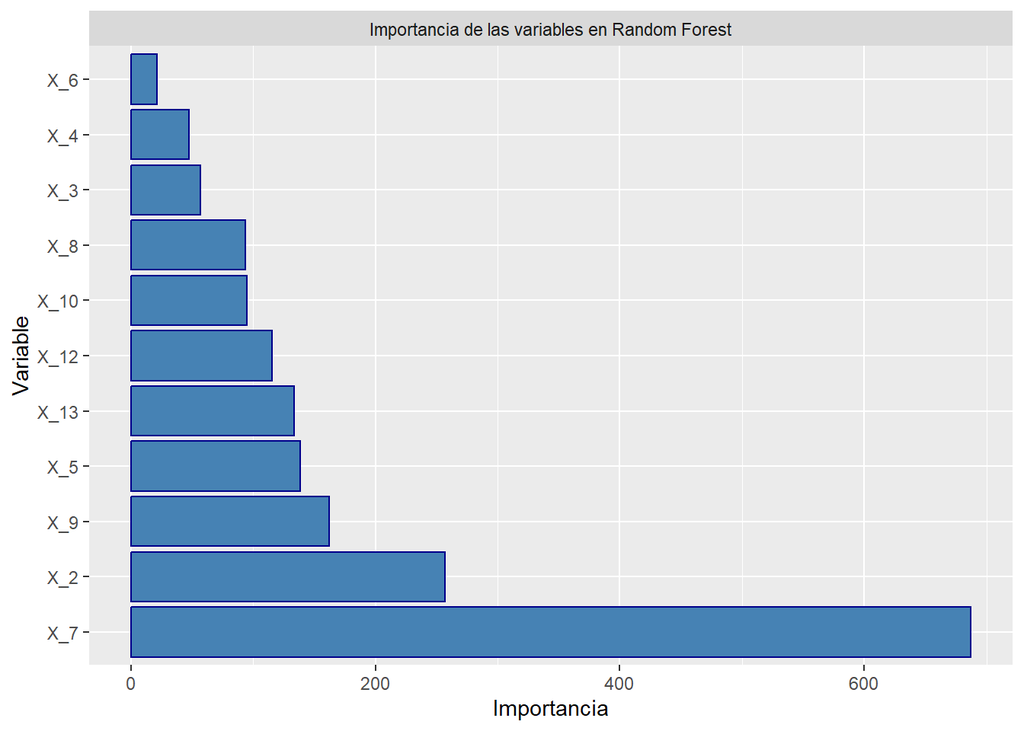

De nuevo, predecimos y calculamos la precisión:

|  | Modelo | Train_Test | Precisión | Kappa | Sensibilidad | Especificidad | Llamada |
| --- | --- | --- | --- | --- | --- | --- | --- |
| 1 | Random_Forest | Train | 0.999473961073119 | 0.998898928786873 | 1 | 0.999131567520625 | forest.fit |
| 2 | Random_Forest | Test | 0.984662576687117 | 0.968413252326567 | 0.985163204747775 | 0.984309623430962 | forest.fit |

### 4.2.10 Máquinas de Vector de Soporte (SVM)

El algoritmo SVM trata de buscar el mejor hiperplano que separa los datos y para ello se apoya en proyectar los datos a otra dimensión, mediante funciones como puede ser por ejemplo, una campana gaussiana.

Se estima con el siguiente código:

```r
# estimacion
svm.fit<- svm(formula, data = df, subset=train,
              type = "C-classification",
              kernel = "radial",
              probability =T)
```

De nuevo predecimos y estimamos la precisión:

|  | Modelo | Train_Test | Precisión | Kappa | Sensibilidad | Especificidad | Llamada |
| --- | --- | --- | --- | --- | --- | --- | --- |
| 1 | SVM | Train | 0.879800105207785 | 0.736534880074676 | 0.719146097398266 | 0.984368215371255 | svm.fit |
| 2 | SVM | Test | 0.885889570552147 | 0.756422451747254 | 0.746290801186944 | 0.984309623430962 | svm.fit |

### 4.2.11 Clasificación mediante red neuronal.

En este caso vamos a emplear una red de perceptrones con una única capa oculta. La red neuronal consiste en estimar mediante descenso de gradiente u otro algoritmo múltiples funciones lineales sobre las que se aplica una función de transformación como por ejemplo la sigmoidea (o logística) y despúes se pone en común el resultado.

Estimamos a modo de ejemplo, una red muy sencilla con tantas neuronas como la ráiz de cuatro veces el número de variables.

```r
net.fit<- nnet(formula, data=df, size = round(sqrt(4*dim(df)[2])),
               maxit=50, decay=0.1, subset=train)
```

Por último, predecimos y estimamos la precisión

|  | Modelo | Train_Test | Precisión | Kappa | Sensibilidad | Especificidad | Llamada |
| --- | --- | --- | --- | --- | --- | --- | --- |
| 1 | Red Neuronal | Train | 0.903997895844292 | 0.795652500430715 | 0.831220813875917 | 0.951367781155015 | net.fit |
| 2 | Red Neuronal | Test | 0.9 | 0.791317474854262 | 0.838278931750742 | 0.943514644351464 | net.fit |

## 4.3 Análisis de la precisión.

En este apartado vamos a comparar la precisión de los modelos y seleccionar el mejor.

Creamos una tabla que resume la precisión de todos los modelos:

|  | Modelo | Train_Test | Precisión | Kappa | Sensibilidad | Especificidad | Llamada |
| --- | --- | --- | --- | --- | --- | --- | --- |
| 1 | Naive Bayes | Train | 0.802998421883219 | 0.59272228523047 | 0.786524349566378 | 0.813721233174121 | nb.fit |
| 2 | Naive Bayes | Test | 0.819631901840491 | 0.630879720490866 | 0.807121661721068 | 0.828451882845188 | nb.fit |
| 3 | KNN | Train | 0.998947922146239 | 0.997796318251754 | 0.99733155436958 | 1 | knn.fit |
| 4 | KNN | Test | 0.962576687116564 | 0.923463693171234 | 0.982195845697329 | 0.948744769874477 | knn.fit |
| 5 | Logistica | Train | 0.870594423987375 | 0.719536897571168 | 0.738492328218812 | 0.956578376031264 | log.fit |
| 6 | Logistica | Test | 0.882208588957055 | 0.751158493338465 | 0.775964391691395 | 0.957112970711297 | log.fit |
| 7 | LDA | Train | 0.867701209889532 | 0.710650374939896 | 0.709806537691795 | 0.970473295701259 | lda.fit |
| 8 | LDA | Test | 0.877914110429448 | 0.74016351026385 | 0.746290801186944 | 0.97071129707113 | lda.fit |
| 9 | QDA | Train | 0.859547606522883 | 0.697128350205881 | 0.738492328218812 | 0.938341293964394 | qda.fit |
| 10 | QDA | Test | 0.862576687116564 | 0.710981011756436 | 0.767062314540059 | 0.929916317991632 | qda.fit |

[output cut: 12 more lines]

Podemos ver la precisión en test ordenada por sensibilidad, que es la precisión en la clase de interés:

|  | Modelo | Train_Test | Precisión | Kappa | Sensibilidad | Especificidad | Llamada |
| --- | --- | --- | --- | --- | --- | --- | --- |
| 1 | Boosting | Test | 0.995092024539877 | 0.989894449696989 | 0.998516320474777 | 0.992677824267782 | boost.fit |
| 2 | Arbol | Test | 0.958895705521472 | 0.916335076448336 | 0.99406528189911 | 0.934100418410042 | tree.fit |
| 3 | Random_Forest | Test | 0.984662576687117 | 0.968413252326567 | 0.985163204747775 | 0.984309623430962 | forest.fit |
| 4 | KNN | Test | 0.962576687116564 | 0.923463693171234 | 0.982195845697329 | 0.948744769874477 | knn.fit |
| 5 | Red Neuronal | Test | 0.9 | 0.791317474854262 | 0.838278931750742 | 0.943514644351464 | net.fit |
| 6 | Bagging | Test | 0.915950920245399 | 0.822640058836704 | 0.820474777448071 | 0.98326359832636 | bag.fit |
| 7 | Naive Bayes | Test | 0.819631901840491 | 0.630879720490866 | 0.807121661721068 | 0.828451882845188 | nb.fit |
| 8 | Logistica | Test | 0.882208588957055 | 0.751158493338465 | 0.775964391691395 | 0.957112970711297 | log.fit |
| 9 | QDA | Test | 0.862576687116564 | 0.710981011756436 | 0.767062314540059 | 0.929916317991632 | qda.fit |
| 10 | LDA | Test | 0.877914110429448 | 0.74016351026385 | 0.746290801186944 | 0.97071129707113 | lda.fit |

[output cut: 1 more lines]

El modelo con mayor sensibilidad en test es:

|  | Modelo | Train_Test | Precisión | Kappa | Sensibilidad | Especificidad | Llamada |
| --- | --- | --- | --- | --- | --- | --- | --- |
| 1 | Boosting | Test | 0.995092024539877 | 0.989894449696989 | 0.998516320474777 | 0.992677824267782 | boost.fit |

Más tarde volveremos a usar esta tabla para recoger el mejor modelo y predecir con él.

# 5) Validación cruzada K-Folds

En este apartado vamos a realizar una validación cruzada en 10 carpetas mediante un loop `for`. Esto consiste en separar los datos en 10 partes, y entrenar los modelos con 9 carpetas y validarlos en 1 y así sucesivamente hasta emplear las 10 carpetas en validación, después usamos el error promedio como un estimador del error de test.

No vamos a mostrar el código del loop ya que es excesivamente extenso, pero lo ejecutamos para obtener los errores de las 10 carpetas por modelo, con los que construimos la siguiente tabla:

|  | Naive_Bayes | knn | logistica | lda | qda | arbol | bagging | boosting | random_forest | svm | net |
| --- | --- | --- | --- | --- | --- | --- | --- | --- | --- | --- | --- |
| 1 | 0.186003683241252 | 0.0368324125230203 | 0.12707182320442 | 0.130755064456722 | 0.136279926335175 | 0.0423572744014733 | 0.130755064456722 | 0.119705340699816 | 0.0128913443830571 | 0.125230202578269 | 0.162062615101289 |
| 2 | 0.142857142857143 | 0.012987012987013 | 0.0909090909090909 | 0.0909090909090909 | 0.0779220779220779 | 0.038961038961039 | 0.0909090909090909 | 0.0909090909090909 | 0.012987012987013 | 0.0909090909090909 | 0.116883116883117 |
| 3 | 0.175675675675676 | 0.0540540540540541 | 0.108108108108108 | 0.108108108108108 | 0.135135135135135 | 0.0675675675675675 | 0.108108108108108 | 0.0945945945945946 | 0.027027027027027 | 0.0945945945945946 | 0.189189189189189 |
| 4 | 0.189189189189189 | 0.0135135135135135 | 0.148648648648649 | 0.121621621621622 | 0.148648648648649 | 0 | 0.121621621621622 | 0.121621621621622 | 0 | 0.121621621621622 | 0.121621621621622 |
| 5 | 0.22972972972973 | 0.0675675675675675 | 0.162162162162162 | 0.148648648648649 | 0.162162162162162 | 0.0540540540540541 | 0.148648648648649 | 0.148648648648649 | 0.0135135135135135 | 0.148648648648649 | 0.175675675675676 |
| 6 | 0.22972972972973 | 0.027027027027027 | 0.135135135135135 | 0.148648648648649 | 0.148648648648649 | 0.0135135135135135 | 0.148648648648649 | 0.135135135135135 | 0 | 0.121621621621622 | 0.121621621621622 |
| 7 | 0.216216216216216 | 0 | 0.121621621621622 | 0.135135135135135 | 0.135135135135135 | 0.027027027027027 | 0.135135135135135 | 0.0945945945945946 | 0.0135135135135135 | 0.121621621621622 | 0.121621621621622 |
| 8 | 0.162162162162162 | 0.0405405405405406 | 0.108108108108108 | 0.148648648648649 | 0.148648648648649 | 0.0540540540540541 | 0.148648648648649 | 0.108108108108108 | 0.0135135135135135 | 0.148648648648649 | 0.162162162162162 |
| 9 | 0.22972972972973 | 0 | 0.0675675675675675 | 0.0945945945945946 | 0.0945945945945946 | 0.0135135135135135 | 0.0945945945945946 | 0.0675675675675675 | 0 | 0.081081081081081 | 0.081081081081081 |
| 10 | 0.243243243243243 | 0.0135135135135135 | 0.216216216216216 | 0.256756756756757 | 0.216216216216216 | 0 | 0.256756756756757 | 0.243243243243243 | 0 | 0.216216216216216 | 0.22972972972973 |

Después, creamos una tabla con los errores promedios y la mostramos ordenada según el error:

|  | Modelo | Error_Medio |
| --- | --- | --- |
| 1 | Random Forest | 0.00934459249376375 |
| 2 | knn | 0.0266035641726249 |
| 3 | Arbol | 0.0311048043092242 |
| 4 | Boosting | 0.122412794512242 |
| 5 | SVM | 0.127019334754141 |
| 6 | Logística | 0.128554848168108 |
| 7 | lda | 0.138382631752798 |
| 8 | Bagging | 0.138382631752798 |
| 9 | qda | 0.140339119344644 |
| 10 | Red Neuronal | 0.148164843468711 |

[output cut: 1 more lines]

Podemos representarlos en un gráfico:

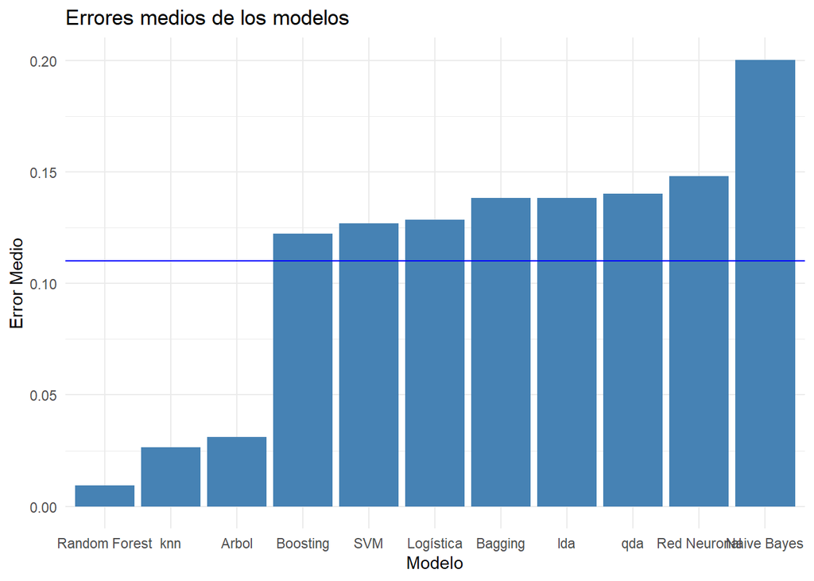

Y además podemos buscar cual es el modelo con menor error:

```
## [1] "Random Forest"
```

# 6) Selección del mejor modelo y predicción

Con la tabla de valores de precisión procedente de train/test podemos recoger el mejor modelo, para ello empleamos la columna `Llamada` y la función `get` para convertir ese `chr` en un objeto de modelo.

```r
# prediccion con el mejor modelo
# llamada mejor modelo

best.fit<-tabla_precision %>%
  filter(Train_Test=='Test') %>%
  arrange(desc(Sensibilidad)) %>%
  slice(1) %>% pull(Llamada) %>% get()
```

Después podemos usarlo para predecir nuestras observaciones no definidas:

```r
# prediccion
(nd$X_1 <- predict(best.fit ,nd)$class)
```

```
## [1] "positivo" "positivo" "negativo" "positivo"
```

Pero antes vamos a ver cuales son los tres mejores modelos y sus pronósticos:

```r
# predicciones de los 3 mejores modelos
top3.fit<-tabla_precision %>%
  filter(Train_Test=='Test') %>%
  arrange(desc(Sensibilidad)) %>%
  slice(1:3) %>% pull(Llamada)

top3.fit
```

```
## [1] "boost.fit"  "tree.fit"   "forest.fit"
```

```r
# top 1

predict(get(top3.fit[1]) ,nd)$class
```

```
## [1] "positivo" "positivo" "negativo" "positivo"
```

```r
# top 2

predict(get(top3.fit[2]) ,nd)
```

```
##   negativo positivo
## 1        0        1
## 2        0        1
## 3        1        0
## 4        0        1
```

```r
# top 3

predict(get(top3.fit[3]) ,nd)
```

```
##        1        2        3        4
## positivo positivo negativo positivo
## Levels: negativo positivo
```

# 7) Conclusiones.

- Los procesos de preparación previa a la aplicación de machine learning son vitales para el rendimiento de estas. Si no se estructuran bien los datos y se solucionan problemas de valores ausentes, ciertos algoritmos pueden dar error. Pero si no se retiran outliers y no se equilibran las probabilidades a priori, los algoritmos pierden mucha precisión.
- Elementos como la buena estructura de un proyecto, la eficiencia del código y la reproducibilidad son de suma importancia tanto para el desarrollo del trabajo como para su reutilización en proyectos futuros.
- La muestra parece recoger multitud de datos anómalos.
- En caso de usar variables cualitativas, la variable tipo de trabajo (fijo, temporal, etc.) parece tener gran poder explicativo, pero no podemos descartar que se trate de una correlación espuria pues lo que influye en la solvencia no es el tipo de contrato en sí, sino el ingreso y su periodicidad que van ligados a dicho tipo de contrato.
- Los modelos no paramétricos dan mejores resultados en nuestros datos, esto se debe a su mayor flexibilidad que les permite adaptarse mejor a la naturaleza del problema.

# 8) Errores y omisiones.

- Un análisis clúster más completo podría ayudar a estudiar y comprender mejor los datos.
- Separar en entrenamiento y test tras aplicar las probabilidades a priori no nos permite detectar la pérdida de generalidad que pudieran implicar, por tanto, sería aconsejable separar un conjunto de validación antes de aplicarlas.
- Podríamos mejorar la selección de las variables para incrementar la precisión de los clasificadores.
- Quizás una reducción de la dimensión permitiera mejorar la detección de outliers y la clasificación.
- Hace falta probar todos los escenarios para decidir cual es el mejor método de detección de outliers y para equilibrar las probabilidades a priori.
- Otra cuestión interesante podría ser realizar un análisis de clasificación en los datos de outliers, tanto para clasificar de forma supervisada en posible outlier como para clasificar dichos outliers en negativo o positivo.